# AASD 4016: Advanced Applied Mathematical Concepts for Deep Learning

### Project 01: "Customizing nanoGPT to Generate Text in the Style of President Donal Trump"

- Jose Lira (101426814)
- Tuo Xin (101409861)

### Problem statement

In this project, we tried to fine tune nanogpt with Donald Trump's rally speeches. We try to figure out if the model can pick up Donald Trump's speaking style. And see how large the dataset should be to avoid overfitting and produce decent result.

### Dataset

We used Kaggle Dataset of full-length speeches that Donald Trump gave in 35 of his rallies.

We used one/five/all of them as the input to the model and benchmarked the result in the table below.

Dataset Link: https://www.kaggle.com/datasets/christianlillelund/donald-trumps-rallies

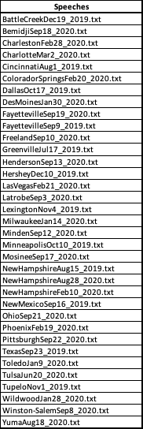

### Environment

• Windows 11

• Python 3.10.9

• PyTorch: torch-1.13.1+cu116 CUDA:0 (NVIDIA GeForce RTX 2060, 6144MiB)

• VSCode 1.75.1

• CUDA: 11.6, V11.6.55

• CUDNN 11.6

• GPU: NVIDIA GeForce RTX 2060

• CPU: 06 Intel Core i7-10750 @2.6Ghz (12 CPUs, 32 GB RAM)

### Training

We run 06 experiments in order to tune and test the nanoGPT model providing combinations of parameters like learning rate, maximum iterations, and amount of full-text speeches provided as input to the model.

### Results

The generated text from tinetuned model with one or five speeches are not readable. Big corpus helps build a more robust model. 'The finetuned model' below refers to the model fine-tuned with 35 speeches.

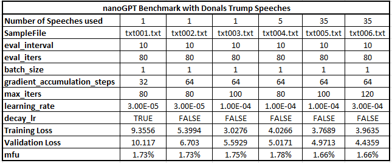

### Experiment 01

Our base model with only one speech, 32 gradient accumulated steps and a low learning rate of 3e-5. We obtain a validation loss of 10.11 and the results were not as expexted as the text has no sense.

### Sample of Experiment 01:

FAM,'s that... league,vesoğten,,, Trying, inconvenient...... OECD......,...,,.,.,.,. legalizing...,,,,. legalizing562,.ourkeadvertisement,..,..,,562. Ethnic strategic,. pedd,.. Mental Electoraligans,,pend. mere,, RecipeShin,,...,.,,, gracious whole. to mattress, Transparency.,. enginesjon irritating,,,,,. ,. swore.... , Header 1904.. Electric,..,,,....,. Brett,,,,,,, crowdfunding,, the,.. the,,,,,,952.,,. motherboard,,...,,igans Resource......,.hole,,,,TL.,,,.'s, imagining you.....,,,,,,..... legalizing.,,,... fruitful,.,,.,,,FIN I.downs,,,...,,hidden,, imagining,..,, legalizing,,.. winner..oldown,.,, dealer ,,,,..,, Site],[,,... 1904 Headerretched,.advertisement WCS..,,,,,,,..,,,.. pushed,,,, wre,,,,,,,. quir,,.,,....... inconvenient,,,,,,,,,,,,,... paper. 1904. squat the,,,,.. I. scaff.,,.... visualize.,,,. the,,..,, Electric, roasted,,, Immigration... dirty,,,1987,,,,,., urgent. Collins,,.,,, Sigma., you,,,,..,. example, inconsistencies're,.,,,,,, siph, fill wre, Dee,,..,,, swore,...,,,,. blending,.him,,.,.,,.. inventor.,,, paper Tup.,,,.,..,,

### Experiment 02

Here we just increased teh gradient accumulated steps to 64 and we got a significant improve in the validation loss to 6.70. Teh text was better but still gramatically and semantically had no sense.

### Sample of Experiment 02

. I'm to four. And you day, I'm not, I said, "Oh, "You." They're going to be here? I really, "You had a lot of the world. And I said, "We Obama, I said, "You 100. I have a lot of the single we're problems, "You's a finished. I said, "You don't In the House. I'm not a lot of the are me. And I said, the we're going to jobs. They're deal. You know what? I said, oh, it's what they're going to be the first? I said, " this. And we're worse and they're going to the. I said, "You have a lot of the economy's a lot of the watch. You know what? I said, answer,, "I was, I don't think we're going to be the. And I said, "You good to me, "You have's going to do, I said, "Oh, ". I said, I said, and we're the water, "Well, you say, " directly the I said, and they're go to damn, and I don't want to the in the of speech, and we've ended it very, "You simple, it's a lot of the history of day, "You have cities, I said, nice, and they're going to Michigan. I said, "Oh, I said, they're going to do that the little, "It's said, " business. I said, "You have a subsidy. I said, and farm ago. I'm not, we're not, "You have with Michigan. I said, and they're going to 10. And that's what I said, "You're going to be. I said, mean, and by the watch, and I think we have enough. I said, you know Hispanic and we're going to me, "You do you. I said, Universities. But . You know, the American people, and they're going to in the office. I'm a remember% of that, I said, "You know what we're going to be the way look, "Hey, "field. How about it's a piece of people, I said, behind I'm not cameras, "I have the yellow% of them, Obama, andThe, I said

### Experiment 03

We increased the maximum iterations to 100 and increased teh learning rate to 1e-4 obtaining an improvement in the validation loss to 5.59. The text is starting to have a littel bit of senses in same phrases but still pretty bad.

### Sample of Experiment 03

. He's the doing's okay? He said, so much. I said, beautiful, because it's anymore. I'm not up? I was really, we tell you want to coming in help. And that they're the been so much. They did. They're going to have a lot of these people. Could you, "You got to do she'd have the hell have them actually. The worst bad people. They didn't Michigan and they don't like crazy. They made we're going to jobs. They're deal with's what coming in the greatest more. They're not going to do, and we have to lose. But I had this. And we're ever had to the Democrats are now. I love it, but I'll say it. So we see the history of our country. You know in this lot of them,, that's a, I don't think they're going to say it. And I didn't have it. time they say, "You's going to do a just us us job. We could be here of this for your time, you know, they care about. But you say, "Oh, I don't know what we go to do, and them than they want to the in Michigan of have a great. And I see very, "You didn't know what? I said, and we're going up. It's great, this is now. But I don't want to by the of them. I said, "Why?" "Well, you know what's going to have a great job. I said, "I had a lot of them to do. We're not ago, " crime I said, we're doing not doing." I Michigan. We're going to have to do that incredible. And that's what they're up, they tell you're going. I was to,, and by the world, you're going to lose, we have to have you know what I'll tell you know, "It's a lot of the world. They're going to do you know an remember, and they don't get a little of a little. But they and they're back. I don't getting up can have the best, they want to over to me, "We're not't have to're doing stuff, right? Thank you want our country. I'm telling you know what they're doing. I've got to do that they don't've ever

### Experiment 04

We increased teh data from 1 speech to 5 full-text speeches. The validation loss decreased to 5.01.

### Sample of Experiment 04

he was a horrible, but they like." I times. He's down to get them, and over and we're the same and he was a minute, "I'll tell you, did that what happened, let that they're what they're going to be great, the wall. We don't get rid of these people that's, look at that one, "You're going to do." And we're the history of it's going to say, that's always going to imagine a lot of say, because the history of China, "We will be a great, but we've done an little bit, "Oh, back to do twoWell, right now we're going to be very much." They had a little while. We will be here up, we're not the polls, "What. And we're going to do it. It's not going to have to the world, we're allowed to?" But we're going to bring them over our country. I said,000 so if it? Because he said, â€¦ What we're very good, it for, and we have to one of your country, because they're going to do we're great say, he's not would not the Constitution of the most important to win that they're not I'm not going to have a the Democrats are going to do as a parking, do it, and a lot of our military said, there, and two days, we have a great job. Oh, "Tra down Obama. I'm not like to have been everybody. We have a friend of on the Democrats are going to do it, history of it's done. I said, we have to do it. They'd going to the president, because they put them back. You know about it's like are going to raise your life, I'm not going to do that? For years. But even want to happen. We've ended the America made a great people of the kids. I do, but we're going to fake news are going to be so many people it. And I think we're going to went out and I don't like a lot of them. But had to do it. I'd see the largest little bit, we're going to come in the most, I said, "How build it ever done get a horrible people remember that, we've have your next single business, I said, and they are, in the Biden's a

### Experiment 05

We increased the number of speechs to 35 and increased the maximum iterations to 100 obtaining an improvement of the validation loss to 4.97.

### Sample of Experiment 05

But these companies. It's impeach him. Where is we have any. Let me. They're getting more. We did a lot of these people, they're against them. We so we had a great deal. You have a great people. They. And we got to be even got a lot of people. But we're so. And I don't have a lot of them. You talk about. And by the attack is for that's going to go into the same way, the middle. You know what a nice. And we got it's by the Senate. We're going to get all over the whole great. He's going to thank you look at a big deal. It's back. Are you bad as us. Did you go home and they made a tree and come in Michigan. We had a lot of you have. I have a half. The biggest because we're doing great deal. with them have a free over. We will be a great with your cars. They read it. Then they're already only they were to have thought you got a little, it's happening. She's will be so opposed to be a to be with nothing. It's other day, when they'll be there. But you know, " ICE, I like I'm not bringing, we have to have it's what? We don't do it. And now, I mean somebody said, they've done that is? And you said, because again, time for your state. He's not going to do it's ever had a disaster." And it's going to do. And I think he said, I've been a great. He's a lot of our country. We're the â€¦ Now, right. They're spending? For me. But all of on a minute. But and they love it. You have a good again. He's an ad. We're going to be been a lot of here. We're did it was a little bit, right? No, we'll be in the world. You have to get up, it. It's a great. There's really said, and you know, "We want to do a little bit. We love you, and here to have to go into our other countries, I'm going to leave. Let's their election? The whole thing. We get in the greatest economy's going up. I'm going to

### Experiment 06

We increased the learning rate to 3e-4 and increased the iterations to 120. The validation loss was 4.43 and the text is legible now, somewhat in the style of Donald Trump.

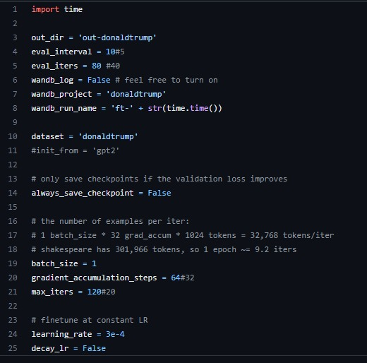

### Lets run Experiment 06 with starting words: "How to make America great again?"

The generate text from nanogpt:

```python
! python sample.py --init_from=gpt2 --start="How to make America great again?"  --num_samples=1 --max_new_tokens=200
```

```
modelpy running
Overriding: init_from = gpt2
Overriding: start = How to make America great again?
Overriding: num_samples = 1
Overriding: max_new_tokens = 200
loading weights from pretrained gpt: gpt2
forcing vocab_size=50257, block_size=1024, bias=True
overriding dropout rate to 0.0
WARNING: using slow attention. Flash Attention requires PyTorch >= 2.0
WARNING: using slow attention. Flash Attention requires PyTorch >= 2.0
WARNING: using slow attention. Flash Attention requires PyTorch >= 2.0
WARNING: using slow attention. Flash Attention requires PyTorch >= 2.0
WARNING: using slow attention. Flash Attention requires PyTorch >= 2.0
WARNING: using slow attention. Flash Attention requires PyTorch >= 2.0
WARNING: using slow attention. Flash Attention requires PyTorch >= 2.0
WARNING: using slow attention. Flash Attention requires PyTorch >= 2.0
WARNING: using slow attention. Flash Attention requires PyTorch >= 2.0
WARNING: using slow attention. Flash Attention requires PyTorch >= 2.0
WARNING: using slow attention. Flash Attention requires PyTorch >= 2.0
WARNING: using slow attention. Flash Attention requires PyTorch >= 2.0
number of parameters: 123.65M
No meta.pkl found, assuming GPT-2 encodings...
How to make America great again?

This is where business owners, consultants, and business leaders come in. They deal with the issues but also have access to information from other actors who have a stake in the outcome of the 2008 campaign and those who have no business involvement with these campaigns. With that knowledge comes a …

I'm going to keep the campaign to only all non-profit organizations. If organizations like the Economic Freedom Network (ERN), the California Poverty Action Network (CPAN) and others are interested in supporting candidates, they can sign up and provide detailed financial and financial disclosures. I…

Governments should be more concerned about giving states the tools to help them organize, educate and mobilize voters and make their communities stronger.

In the next few days we'll be publishing the story of "Raising Democracy for America." Our list highlights elected representatives, lawmakers, and
---------------
```

The generated text from fine-tuned model:

```python
! python sample.py --init_from=resume --start="How to make America great again?"  --num_samples=1 --max_new_tokens=200
```

```
modelpy running
Overriding: init_from = resume
Overriding: start = How to make America great again?
Overriding: num_samples = 1
Overriding: max_new_tokens = 200
WARNING: using slow attention. Flash Attention requires PyTorch >= 2.0
WARNING: using slow attention. Flash Attention requires PyTorch >= 2.0
WARNING: using slow attention. Flash Attention requires PyTorch >= 2.0
WARNING: using slow attention. Flash Attention requires PyTorch >= 2.0
WARNING: using slow attention. Flash Attention requires PyTorch >= 2.0
WARNING: using slow attention. Flash Attention requires PyTorch >= 2.0
WARNING: using slow attention. Flash Attention requires PyTorch >= 2.0
WARNING: using slow attention. Flash Attention requires PyTorch >= 2.0
WARNING: using slow attention. Flash Attention requires PyTorch >= 2.0
WARNING: using slow attention. Flash Attention requires PyTorch >= 2.0
WARNING: using slow attention. Flash Attention requires PyTorch >= 2.0
WARNING: using slow attention. Flash Attention requires PyTorch >= 2.0
number of parameters: 123.59M
No meta.pkl found, assuming GPT-2 encodings...
How to make America great again? I don't happen to do. He said, by the beginning. The next one. Great, they're going to what it's good. They're going to be seeing it, and they're going to this guy, that you. And we're going to go back and they're not a great, because is the day. So he says, which is…
---------------
```

### Summary

The model picked up two significant characters:

1. Use easy words: Danald Trump is famous for his habits of using easy words at the level of every kid can understand.
2. Short sentences: Compared to pretrained model trained from open webtext. Speeches contains lots of spoken short sentences.

Model Problems:

1. Speeches are not training materials as the coherence between sentences is not good, compared to novals and webtexts.
2. Filler words and repetitive phrases interupts the flow. For example: "I took you on this fantastic journey. It's so much fun. They want to impeach you. They want to do worse than that. By the way, by the way, by the way, it doesn't really feel like we're being impeached." Note that 'by the way' repeated 3 times, which badly influences a generative model.
3. We need larger dataset to produce a better model.

### Exploration

Then we put generated text to OpenAI ai text classififer that detect if a text is generated by an AI.

Interestingly, both generated text got the same result: The classifier considers the text to be unclear if it is AI-generated.

### References

- [1] Karpahty, "nanoGPT", (2023). URL: https://github.com/karpathy/nanoGPT
- [2] OpenAI, "AI Text Classifier", (2023). URL: https://platform.openai.com/ai-text-classifier
- [3] Kaggle,"Donald Trump Rally Speeches" (2020). URL: https://www.kaggle.com/datasets/christianlillelund/donald-trumps-rallies